# Using Dropout for Classification and Regression

Created on JupyterLab

## Table of Contents

- Using Dropout for Classification
- Make Some Data
- Create the Model and Cost Function the PyTorch way
- Batch Gradient Descent
- Using dropout in regression
- Make Some Data
- Create the Model and Cost Function the PyTorch way
- Batch Gradient Descent

# Using Dropout for Classification

### Objective for this Notebook

We are going to discuss about the dropout method. This method improves the performance of deep neural networks.

In particular we will talk about **dropout, a method used to prevent over fitting.** We will show how to implement the dropout method in PyTorch.

Let's say, we have a decision boundary that separates samples into two classes, on one side of the decision boundary we have y=1 which is represented as red, and on the other side of the decision boundary we have y=0 which is represented as blue.

In the real world, it is highly unlikely that we have a sample that can be cleanly separated by a decision boundary. The sample os generally noisy, that means some data will fall on the wrong side of the decision boundary. **If we use too many parameters in our neural network model, for example, too many layers or too many neurons, we risk overfitting. If our model is overly simplified, we risk underfitting.**

We could try different combinations of the number of neurons and layers, but it will take too much time and resources.

**A solution is to start with a model that is complex, and apply a form of regularization call dropout. Dropout is a popular regularization technique use exclusively for neural networks. Dropout involve two phases: The training phase is where we implement the dropout method. And the evaluation phase, where we turn off the drop out method to test the performance of our model.**

The dropout is implemented by **multiplying the activation function with the Bernoulli random variable r. The Bernoulli distribution is a discrete probability distribution where the random variable r takes on the value 0 with probability p, and takes on the value 1 with the probability 1 - p. So if p is 0.5 it's like flipping a fair coin, r=0 with probability p or probability of heads, r=1 with the same probability as tails.**

Let's see how we implement the dropout method. In the l th layer of the neural network, we multiply the activation function of each element in the layer **with a Bernoulli distributed random variable r.** R take on the value 0 with probability p and r takes on the value 1 with probability 1-p. **In this case if r_1 equals 0, we are shutting off the first neuron in the layer or the first element in the vector.**

We have our neural network, we apply dropout to the hidden layers during the forward step while training. We also have a probability p, and this tells us how likely we are to shut off a neuron. **Each neuron is independent of each other and each iteration. So if one neuron is shut off, it does not affect the probability that the other neurons being shut off in the same layer or another neuron being shut off in another layer.**

In the Forward step for the first iteration we shut off some neurons in each layer each with a probably of 0.2. This is done by multiplying the activation function by zero. For the second training iteration, we randomly turn several neurons off. As you can see, it is a different set of neurons being turned off in this iteration, than the set of neurons being turned off in the previous iteration. Then we calculate the forward step.

The process is repeated for each iteration of training. PyTorch normalizes the values in the training phase of each activation by dividing with the value 1 minus p. This is due to the expected value of each neuron being turned on is 1 minus p. **The larger p the more neurons we remove, thus preventing overfitting. If p=0.8 we expect that the majority of neurons to not be active. If p equals one, then all the neurons will be multiplied by zero.**

**Generally the more neurons the larger value of p should be used. For the layers with less neurons we use values for p between 0.1 and 0.05. For the layers with more neurons we use a value for p of 0.5.**

For the **evaluation** we do not multiply the activation function with the Bernoulli random variable r. We simply run the neural network **with all the neurons being active.**

**The parameter p is a hyper parameter we can obtain the optimal value of p through cross validation.** If the value of p is to small we risk overfitting. If the value of p is to large we risk underfitting.

## Preparation

We'll need the following libraries

```python
import torch
import matplotlib.pyplot as plt
import torch.nn as nn
import torch.nn.functional as F
import numpy as np
from matplotlib.colors import ListedColormap
from torch.utils.data import Dataset, DataLoader
```

Use this function only for plotting:

```python
# The function for plotting the diagram

def plot_decision_regions_3class(data_set, model=None):
    cmap_light = ListedColormap([ '#0000FF','#FF0000'])
    cmap_bold = ListedColormap(['#FF0000', '#00FF00', '#00AAFF'])
    X = data_set.x.numpy()
    y = data_set.y.numpy()
    h = .02
    x_min, x_max = X[:, 0].min() - 0.1, X[:, 0].max() + 0.1
    y_min, y_max = X[:, 1].min() - 0.1, X[:, 1].max() + 0.1
    xx, yy = np.meshgrid(np.arange(x_min, x_max, h), np.arange(y_min, y_max, h))
    newdata = np.c_[xx.ravel(), yy.ravel()]

    Z = data_set.multi_dim_poly(newdata).flatten()
    f = np.zeros(Z.shape)
    f[Z > 0] = 1
    f = f.reshape(xx.shape)
    if model != None:
        model.eval()
        XX = torch.Tensor(newdata)
        _, yhat = torch.max(model(XX), 1)
        yhat = yhat.numpy().reshape(xx.shape)
        plt.pcolormesh(xx, yy, yhat, cmap=cmap_light)
        plt.contour(xx, yy, f, cmap=plt.cm.Paired)
    else:
        plt.contour(xx, yy, f, cmap=plt.cm.Paired)
        plt.pcolormesh(xx, yy, f, cmap=cmap_light)

    plt.title("decision region vs True decision boundary")
```

Use this function to calculate accuracy:

```python
# The function for calculating accuracy

def accuracy(model, data_set):
    _, yhat = torch.max(model(data_set.x), 1)
    return (yhat == data_set.y).numpy().mean()
```

## Make Some Data

Create a nonlinearly separable dataset:

```python
# Create data class for creating dataset object

class Data(Dataset):

    # Constructor
    def __init__(self, N_SAMPLES=1000, noise_std=0.15, train=True):
        a = np.matrix([-1, 1, 2, 1, 1, -3, 1]).T
        self.x = np.matrix(np.random.rand(N_SAMPLES, 2))
        self.f = np.array(a[0] + (self.x) * a[1:3] + np.multiply(self.x[:, 0], self.x[:, 1]) * a[4] + np.multiply(self.x, self.x) * a[5:7]).flatten()
        self.a = a

        self.y = np.zeros(N_SAMPLES)
        self.y[self.f > 0] = 1
        self.y = torch.from_numpy(self.y).type(torch.LongTensor)
        self.x = torch.from_numpy(self.x).type(torch.FloatTensor)
        self.x = self.x + noise_std * torch.randn(self.x.size())
        self.f = torch.from_numpy(self.f)
        self.a = a
        if train == True:
            torch.manual_seed(1)
            self.x = self.x + noise_std * torch.randn(self.x.size())
            torch.manual_seed(0)

    # Getter
    def __getitem__(self, index):
        return self.x[index], self.y[index]

    # Get Length
    def __len__(self):
        return self.len

    # Plot the diagram
    def plot(self):
        X = data_set.x.numpy()
        y = data_set.y.numpy()
        h = .02
        x_min, x_max = X[:, 0].min(), X[:, 0].max()
        y_min, y_max = X[:, 1].min(), X[:, 1].max()
        xx, yy = np.meshgrid(np.arange(x_min, x_max, h), np.arange(y_min, y_max, h))
        Z = data_set.multi_dim_poly(np.c_[xx.ravel(), yy.ravel()]).flatten()
        f = np.zeros(Z.shape)
        f[Z > 0] = 1
        f = f.reshape(xx.shape)

        plt.title('True decision boundary  and sample points with noise ')
        plt.plot(self.x[self.y == 0, 0].numpy(), self.x[self.y == 0,1].numpy(), 'bo', label='y=0')
        plt.plot(self.x[self.y == 1, 0].numpy(), self.x[self.y == 1,1].numpy(), 'ro', label='y=1')
        plt.contour(xx, yy, f,cmap=plt.cm.Paired)
        plt.xlim(0,1)
        plt.ylim(0,1)
        plt.legend()

    # Make a multidimension ploynomial function
    def multi_dim_poly(self, x):
        x = np.matrix(x)
        out = np.array(self.a[0] + (x) * self.a[1:3] + np.multiply(x[:, 0], x[:, 1]) * self.a[4] + np.multiply(x, x) * self.a[5:7])
        out = np.array(out)
        return out
```

Create a dataset object:

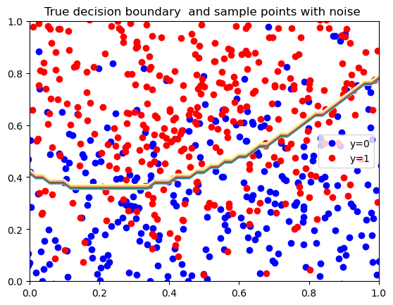

```python
# Create a dataset object

data_set = Data(noise_std=0.2)
data_set.plot()
```

Validation data:

```python
# Get some validation data

torch.manual_seed(0)
validation_set = Data(train=False)
```

## Create the Model, Optimizer, and Total Loss Function (Cost)

Create a custom module with three layers. `in_size` is the size of the input features, `n_hidden` is the size of the layers, and `out_size` is the size. **`p` is the dropout probability. The default is 0, that is, no dropout.**

```python
# Create Net Class

class Net(nn.Module):

    # Constructor
    def __init__(self, in_size, n_hidden, out_size, p=0):
        super(Net, self).__init__()
        self.drop = nn.Dropout(p=p)
        self.linear1 = nn.Linear(in_size, n_hidden)
        self.linear2 = nn.Linear(n_hidden, n_hidden)
        self.linear3 = nn.Linear(n_hidden, out_size)

    # Prediction function
    def forward(self, x):
        x = F.relu(self.drop(self.linear1(x)))
        x = F.relu(self.drop(self.linear2(x)))
        x = self.linear3(x)
        return x
```

Create two model objects: `model` had no dropout and `model_drop` has a dropout probability of 0.5:

```python
# Create two model objects: model without dropout and model with dropout

model = Net(2, 300, 2)
model_drop = Net(2, 300, 2, p=0.5)
```

## Train the Model via Batch Gradient Descent

Set the model using dropout to training mode; this is the default mode, but it's good practice to write this in your code :

```python
# Set the model to training mode

model_drop.train()
```

```
Net(
  (drop): Dropout(p=0.5, inplace=False)
  (linear1): Linear(in_features=2, out_features=300, bias=True)
  (linear2): Linear(in_features=300, out_features=300, bias=True)
  (linear3): Linear(in_features=300, out_features=2, bias=True)
)
```

Train the model by using the Adam optimizer. See the unit on other optimizers. Use the Cross Entropy Loss:

```python
# Set optimizer functions and criterion functions

optimizer_ofit = torch.optim.Adam(model.parameters(), lr=0.01)
optimizer_drop = torch.optim.Adam(model_drop.parameters(), lr=0.01)
criterion = torch.nn.CrossEntropyLoss()
```

Initialize a dictionary that stores the training and validation loss for each model:

```python
# Initialize the LOSS dictionary to store the loss

LOSS = {}
LOSS['training data no dropout'] = []
LOSS['validation data no dropout'] = []
LOSS['training data dropout'] = []
LOSS['validation data dropout'] = []
```

Run 500 iterations of batch gradient gradient descent:

```python
# Train the model

epochs = 500

def train_model(epochs):

    for epoch in range(epochs):
        #all the samples are used for training
        yhat = model(data_set.x)
        yhat_drop = model_drop(data_set.x)
        loss = criterion(yhat, data_set.y)
        loss_drop = criterion(yhat_drop, data_set.y)

        #store the loss for both the training and validation data for both models
        LOSS['training data no dropout'].append(loss.item())
        LOSS['validation data no dropout'].append(criterion(model(validation_set.x), validation_set.y).item())
        LOSS['training data dropout'].append(loss_drop.item())
        model_drop.eval()
        LOSS['validation data dropout'].append(criterion(model_drop(validation_set.x), validation_set.y).item())
        model_drop.train()

        optimizer_ofit.zero_grad()
        optimizer_drop.zero_grad()
        loss.backward()
        loss_drop.backward()
        optimizer_ofit.step()
        optimizer_drop.step()

train_model(epochs)
```

Set the model with dropout to evaluation mode:

```python
# Set the model to evaluation model

model_drop.eval()
```

```
Net(
  (drop): Dropout(p=0.5, inplace=False)
  (linear1): Linear(in_features=2, out_features=300, bias=True)
  (linear2): Linear(in_features=300, out_features=300, bias=True)
  (linear3): Linear(in_features=300, out_features=2, bias=True)
)
```

Test the model without dropout on the validation data:

```python
# Print out the accuracy of the model without dropout

print("The accuracy of the model without dropout: ", accuracy(model, validation_set))
```

```
The accuracy of the model without dropout:  0.814
```

Test the model with dropout on the validation data:

```python
# Print out the accuracy of the model with dropout

print("The accuracy of the model with dropout: ", accuracy(model_drop, validation_set))
```

```
The accuracy of the model with dropout:  0.864
```

You see that the model with dropout performs better on the validation data.

### True Function

Plot the decision boundary and the prediction of the networks in different colors.

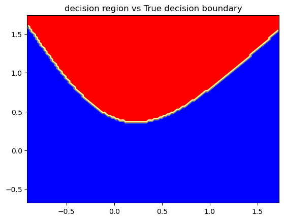

```python
# Plot the decision boundary and the prediction

plot_decision_regions_3class(data_set)
```

Model without Dropout:

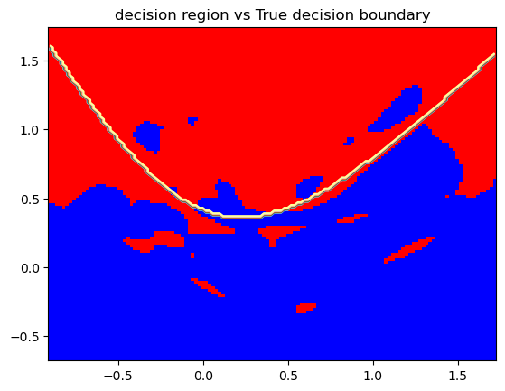

```python
# The model without dropout

plot_decision_regions_3class(data_set, model)
```

Model with Dropout:

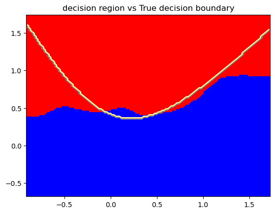

```python
# The model with dropout

plot_decision_regions_3class(data_set, model_drop)
```

You can see that the model using dropout does better at tracking the function that generated the data.

Plot out the loss for the training and validation data on both models, we use the log to make the difference more apparent

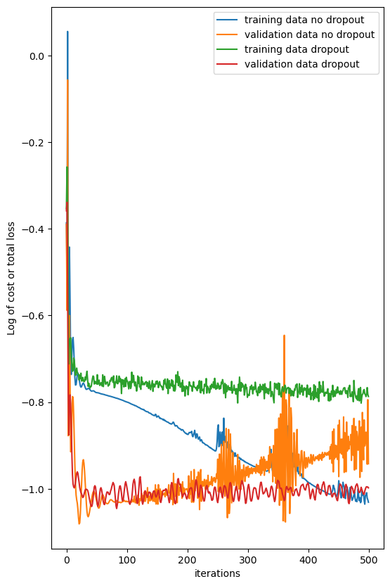

```python
# Plot the LOSS

plt.figure(figsize=(6.1, 10))
def plot_LOSS():
    for key, value in LOSS.items():
        plt.plot(np.log(np.array(value)), label=key)
        plt.legend()
        plt.xlabel("iterations")
        plt.ylabel("Log of cost or total loss")

plot_LOSS()
```

**You see that the model without dropout performs better on the training data, but it performs worse on the validation data. This suggests overfitting.**

**However, the model using dropout performed better on the validation data, but worse on the training data.**

# Using Dropout in Regression

### Objective:

## Preparation

We'll need the following libraries

```python
import torch
import matplotlib.pyplot as plt
import torch.nn as nn
import torch.nn.functional as F
import numpy as np
from torch.utils.data import Dataset, DataLoader

torch.manual_seed(0)
```

```
<torch._C.Generator at 0x7f07bc03fdb0>
```

## Make Some Data

Create polynomial dataset class:

```python
# Create Data object

class Data(Dataset):

    # Constructor
    def __init__(self, N_SAMPLES=40, noise_std=1, train=True):
        self.x = torch.linspace(-1, 1, N_SAMPLES).view(-1, 1)
        self.f = self.x ** 2
        if train != True:
            torch.manual_seed(1)
            self.y = self.f + noise_std * torch.randn(self.f.size())
            self.y = self.y.view(-1, 1)
            torch.manual_seed(0)
        else:
            self.y = self.f + noise_std * torch.randn(self.f.size())
            self.y = self.y.view(-1, 1)

    # Getter
    def __getitem__(self, index):
        return self.x[index], self.y[index]

    # Get Length
    def __len__(self):
        return self.len

    # Plot the data
    def plot(self):
        plt.figure(figsize = (6.1, 10))
        plt.scatter(self.x.numpy(), self.y.numpy(), label="Samples")
        plt.plot(self.x.numpy(), self.f.numpy() ,label="True Function", color='orange')
        plt.xlabel("x")
        plt.ylabel("y")
        plt.xlim((-1, 1))
        plt.ylim((-2, 2.5))
        plt.legend(loc="best")
        plt.show()
```

Create a dataset object:

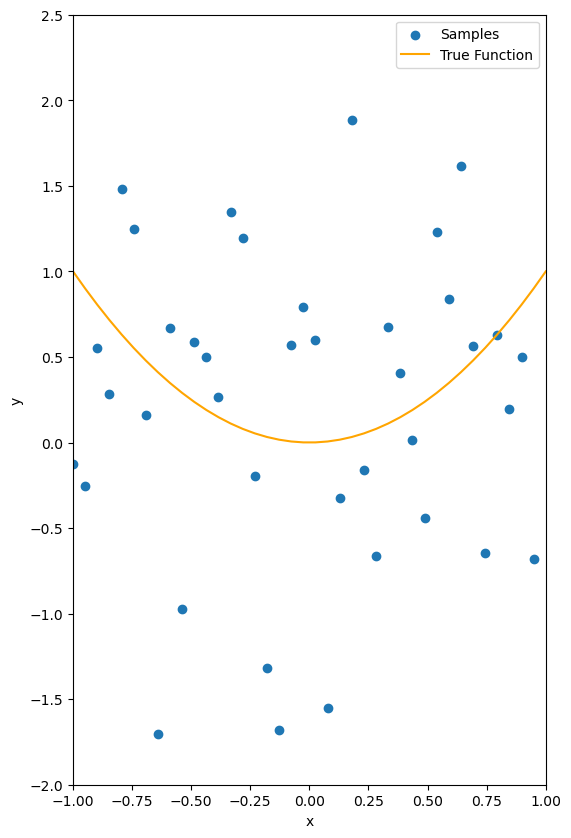

```python
# Create the dataset object and plot the dataset

data_set = Data()
data_set.plot()
```

Get some validation data:

```python
# Create validation dataset object

validation_set = Data(train=False)
```

## Create the Model, Optimizer, and Total Loss Function (Cost)

Create a custom module with three layers. `in_size` is the size of the input features, `n_hidden` is the size of the layers, and `out_size` is the size. `p` is dropout probability. The default is 0 which is no dropout.

```python
# Create the class for model

class Net(nn.Module):

    # Constructor
    def __init__(self, in_size, n_hidden, out_size, p=0):
        super(Net, self).__init__()
        self.drop = nn.Dropout(p=p)
        self.linear1 = nn.Linear(in_size, n_hidden)
        self.linear2 = nn.Linear(n_hidden, n_hidden)
        self.linear3 = nn.Linear(n_hidden, out_size)

    def forward(self, x):
        x = F.relu(self.drop(self.linear1(x)))
        x = F.relu(self.drop(self.linear2(x)))
        x = self.linear3(x)
        return x
```

Create two model objects: `model` had no dropout, and `model_drop has a dropout probability of 0.5:`

```python
# Create the model objects

model = Net(1, 300, 1)
model_drop = Net(1, 300, 1, p=0.5)
```

## Train the Model via Batch Gradient Descent

Set the model using dropout to training mode; this is the default mode, but it's good practice.

```python
# Set the model to train mode

model_drop.train()
```

```
Net(
  (drop): Dropout(p=0.5, inplace=False)
  (linear1): Linear(in_features=1, out_features=300, bias=True)
  (linear2): Linear(in_features=300, out_features=300, bias=True)
  (linear3): Linear(in_features=300, out_features=1, bias=True)
)
```

Train the model by using the Adam optimizer. See the unit on other optimizers. Use the mean square loss:

```python
# Set the optimizer and criterion function

optimizer_ofit = torch.optim.Adam(model.parameters(), lr=0.01)
optimizer_drop = torch.optim.Adam(model_drop.parameters(), lr=0.01)
criterion = torch.nn.MSELoss()
```

Initialize a dictionary that stores the training and validation loss for each model:

```python
# Initialize the dict to contain the loss results

LOSS={}
LOSS['training data no dropout']=[]
LOSS['validation data no dropout']=[]
LOSS['training data dropout']=[]
LOSS['validation data dropout']=[]
```

Run 500 iterations of batch gradient descent:

```python
# Train the model

epochs = 500

def train_model(epochs):
    for epoch in range(epochs):
        yhat = model(data_set.x)
        yhat_drop = model_drop(data_set.x)
        loss = criterion(yhat, data_set.y)
        loss_drop = criterion(yhat_drop, data_set.y)

        #store the loss for  both the training and validation  data for both models
        LOSS['training data no dropout'].append(loss.item())
        LOSS['validation data no dropout'].append(criterion(model(validation_set.x), validation_set.y).item())
        LOSS['training data dropout'].append(loss_drop.item())
        model_drop.eval()
        LOSS['validation data dropout'].append(criterion(model_drop(validation_set.x), validation_set.y).item())
        model_drop.train()

        optimizer_ofit.zero_grad()
        optimizer_drop.zero_grad()
        loss.backward()
        loss_drop.backward()
        optimizer_ofit.step()
        optimizer_drop.step()

train_model(epochs)
```

Set the model with dropout to evaluation mode:

```python
# Set the model with dropout to evaluation mode

model_drop.eval()
```

```
Net(
  (drop): Dropout(p=0.5, inplace=False)
  (linear1): Linear(in_features=1, out_features=300, bias=True)
  (linear2): Linear(in_features=300, out_features=300, bias=True)
  (linear3): Linear(in_features=300, out_features=1, bias=True)
)
```

Make a prediction by using both models:

```python
# Make the prediction

yhat = model(data_set.x)
yhat_drop = model_drop(data_set.x)
```

Plot predictions of both models. Compare them to the training points and the true function:

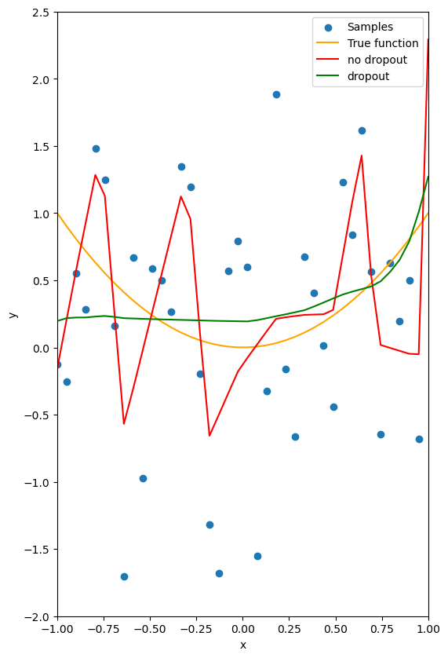

```python
# Plot the predictions for both models

plt.figure(figsize=(6.1, 10))

plt.scatter(data_set.x.numpy(), data_set.y.numpy(), label="Samples")
plt.plot(data_set.x.numpy(), data_set.f.numpy(), label="True function", color='orange')
plt.plot(data_set.x.numpy(), yhat.detach().numpy(), label='no dropout', c='r')
plt.plot(data_set.x.numpy(), yhat_drop.detach().numpy(), label="dropout", c ='g')

plt.xlabel("x")
plt.ylabel("y")
plt.xlim((-1, 1))
plt.ylim((-2, 2.5))
plt.legend(loc = "best")
plt.show()
```

You can see that the model using dropout does better at tracking the function that generated the data. We use the log to make the difference more apparent

Plot out the loss for training and validation data on both models:

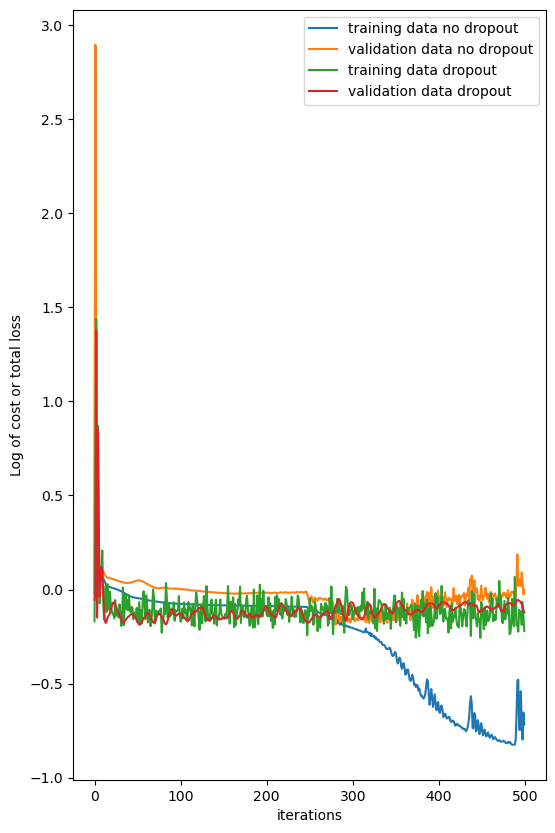

```python
# Plot the loss

plt.figure(figsize=(6.1, 10))
for key, value in LOSS.items():
    plt.plot(np.log(np.array(value)), label=key)
    plt.legend()
    plt.xlabel("iterations")
    plt.ylabel("Log of cost or total loss")
```

**You see that the model without dropout performs better on the training data, but it performs worse on the validation data. This suggests overfitting. However, the model using dropout performs better on the validation data, but worse on the training data**

# Authors' rights

Machine Learning with Python course by IBM on Coursera: https://www.coursera.org/learn/machine-learning-with-python/

Completed and modified by Mathilde Marie Duville as part of the IBM Artificial Intelligence Engineering Professional Certificate and corresponding IBM badges. Please, follow the subsequent links to confirm the accreditation:

https://www.coursera.org/account/accomplishments/professional-cert/KSLW773DAATP?utm_source=link&utm_medium=certificate&utm_content=cert_image&utm_campaign=sharing_cta&utm_product=prof

https://www.credly.com/users/mathilde-marie-duville/badges

Author: [Joseph Santarcangelo](https://www.linkedin.com/in/joseph-s-50398b136/) has a PhD in Electrical Engineering, his research focused on using machine learning, signal processing, and computer vision to determine how videos impact human cognition. Joseph has been working for IBM since he completed his PhD.

Other contributors: [Michelle Carey](https://www.linkedin.com/in/michelleccarey/), Mavis Zhou